# Report Analysis Birthweight

# 1 Birth weights

## 1.1 Time series

No significant changes in birth weight 1918 and 1919. But birth weights increase (breakpoint) in May 1919 (week 27).  
Weekly

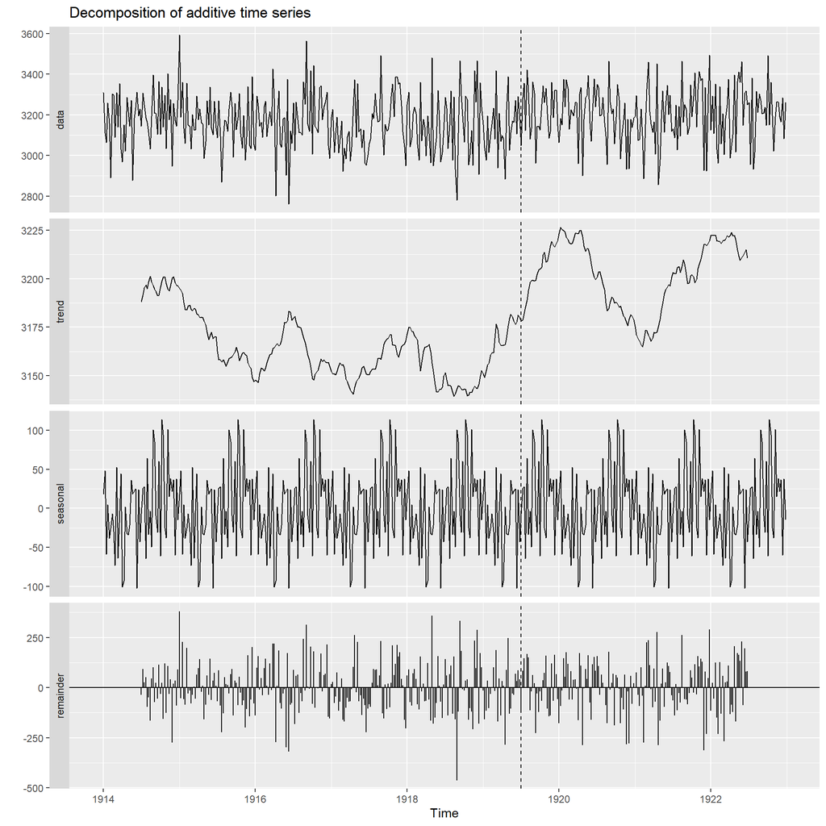

Monthly

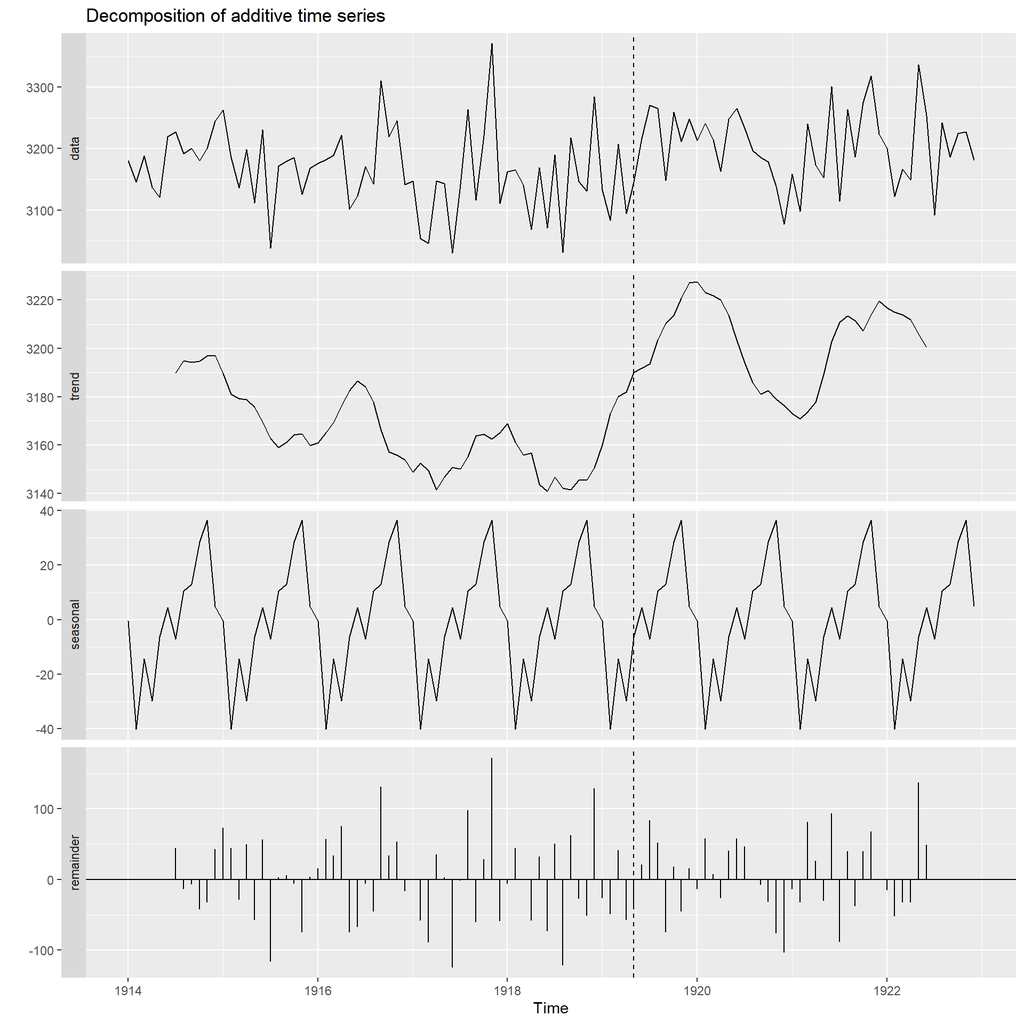

## 1.2 unadjusted

The quantile regression does not provide any further information. The results are similar when using the quantile and linear regressions. No significant differences between the quantiles are found for the years 1918 and 1919.  
Lineare regression

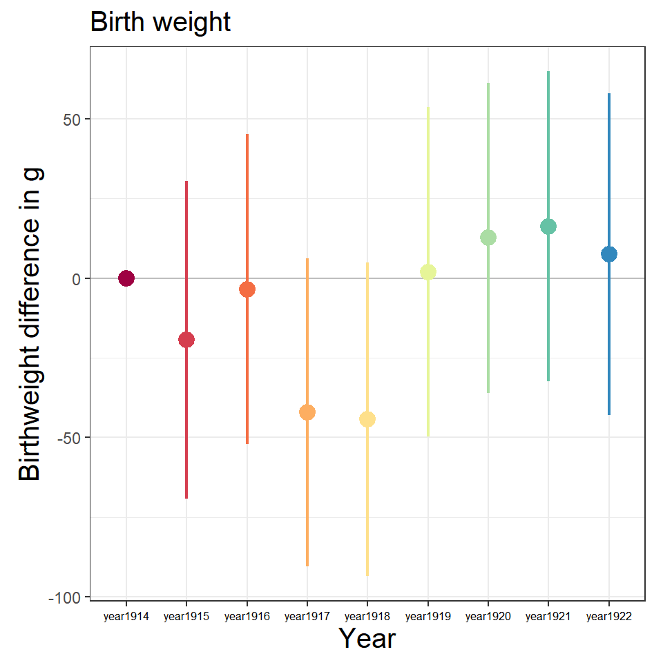

Quantile regression

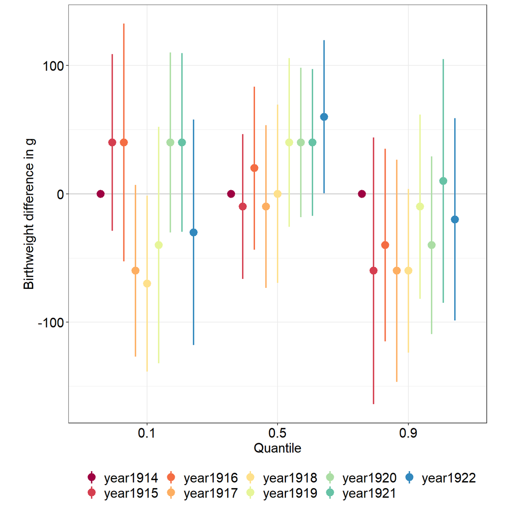

Lineare regression only Exposure

```
##
## Call:
## lm(formula = weight ~ Exposure_sum, data = datared)
##
## Residuals:
##      Min       1Q   Median       3Q      Max
## -1678.72  -308.72     1.28   311.28  2081.28
##
## Coefficients:
##              Estimate Std. Error t value Pr(>|t|)
## (Intercept)  3178.723      6.496 489.310   <2e-16 ***
## Exposure_sum    4.380      6.969   0.629     0.53
## ---
## Signif. codes:  0 '***' 0.001 '**' 0.01 '*' 0.05 '.' 0.1 ' ' 1
##
## Residual standard error: 484.7 on 6589 degrees of freedom
## Multiple R-squared:  5.996e-05,  Adjusted R-squared:  -9.18e-05
## F-statistic: 0.3951 on 1 and 6589 DF,  p-value: 0.5297
```

Lineare regression only flu intensity

```
##
## Call:
## lm(formula = weight ~ Flu_intensity_all, data = datared)
##
## Residuals:
##      Min       1Q   Median       3Q      Max
## -1679.76  -309.76     0.24   310.24  2080.24
##
## Coefficients:
##                   Estimate Std. Error t value Pr(>|t|)
## (Intercept)       3179.762      6.285 505.917   <2e-16 ***
## Flu_intensity_all    9.639     33.166   0.291    0.771
## ---
## Signif. codes:  0 '***' 0.001 '**' 0.01 '*' 0.05 '.' 0.1 ' ' 1
##
## Residual standard error: 484.7 on 6589 degrees of freedom
## Multiple R-squared:  1.282e-05,  Adjusted R-squared:  -0.0001389
## F-statistic: 0.08446 on 1 and 6589 DF,  p-value: 0.7713
```

GAM regression

```
##
## Family: gaussian
## Link function: identity
##
## Formula:
## weight ~ s(Birth_year_week_num, k = 20) + s(birth_month, bs = "cc",
##     k = 12)
##
## Parametric coefficients:
##             Estimate Std. Error t value Pr(>|t|)
## (Intercept) 3180.332      5.965   533.2   <2e-16 ***
## ---
## Signif. codes:  0 '***' 0.001 '**' 0.01 '*' 0.05 '.' 0.1 ' ' 1
##
## Approximate significance of smooth terms:
##                          edf Ref.df     F p-value
## s(Birth_year_week_num) 2.561  3.199 2.322  0.0756 .
## s(birth_month)         1.653 10.000 0.500  0.0312 *
## ---
## Signif. codes:  0 '***' 0.001 '**' 0.01 '*' 0.05 '.' 0.1 ' ' 1
##
## R-sq.(adj) =  0.00177   Deviance explained = 0.24%
## GCV = 2.3469e+05  Scale est. = 2.345e+05  n = 6591
```

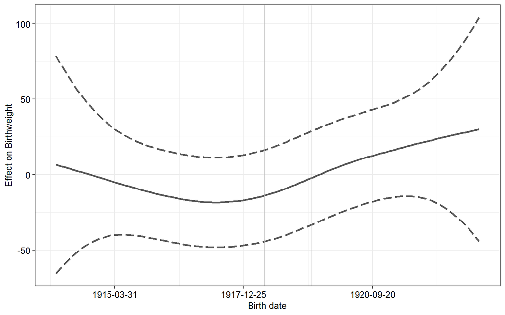

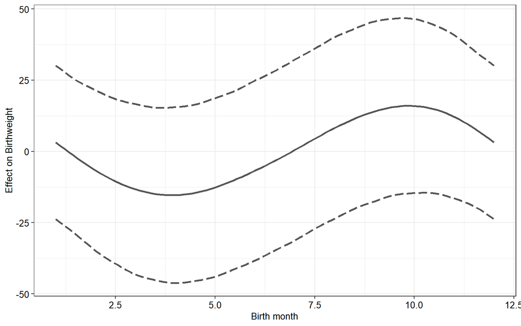

GAM regression and Exposure

```
##
## Family: gaussian
## Link function: identity
##
## Formula:
## weight ~ s(Birth_year_week_num, k = 20) + s(birth_month, bs = "cc",
##     k = 12) + Exposure_sum
##
## Parametric coefficients:
##              Estimate Std. Error t value Pr(>|t|)
## (Intercept)  3177.667      6.663 476.909   <2e-16 ***
## Exposure_sum    7.253      8.080   0.898    0.369
## ---
## Signif. codes:  0 '***' 0.001 '**' 0.01 '*' 0.05 '.' 0.1 ' ' 1
##
## Approximate significance of smooth terms:
##                          edf Ref.df     F p-value
## s(Birth_year_week_num) 2.296  2.868 2.930  0.0618 .
## s(birth_month)         1.614 10.000 0.469  0.0363 *
## ---
## Signif. codes:  0 '***' 0.001 '**' 0.01 '*' 0.05 '.' 0.1 ' ' 1
##
## R-sq.(adj) =  0.00173   Deviance explained = 0.247%
## GCV = 2.3472e+05  Scale est. = 2.3451e+05  n = 6591
```

GAM regression and flu intensity

```
##
## Family: gaussian
## Link function: identity
##
## Formula:
## weight ~ s(Birth_year_week_num, k = 20) + s(birth_month, bs = "cc",
##     k = 12) + Flu_intensity_all
##
## Parametric coefficients:
##                   Estimate Std. Error t value Pr(>|t|)
## (Intercept)       3178.839      6.344 501.117   <2e-16 ***
## Flu_intensity_all   25.225     36.456   0.692    0.489
## ---
## Signif. codes:  0 '***' 0.001 '**' 0.01 '*' 0.05 '.' 0.1 ' ' 1
##
## Approximate significance of smooth terms:
##                          edf Ref.df     F p-value
## s(Birth_year_week_num) 2.458   3.07 2.482  0.0615 .
## s(birth_month)         1.673  10.00 0.514  0.0291 *
## ---
## Signif. codes:  0 '***' 0.001 '**' 0.01 '*' 0.05 '.' 0.1 ' ' 1
##
## R-sq.(adj) =  0.00171   Deviance explained = 0.249%
## GCV = 2.3473e+05  Scale est. = 2.3451e+05  n = 6591
```

## 1.3 adjusted

Lineare regression

Exposure sum

```
##
## Call:
## lm(formula = weight ~ year + boy + parity + Gest_group + birth_month +
##     matage + married + city + insurance + Exposure_sum, data = datared)
##
## Residuals:
##      Min       1Q   Median       3Q      Max
## -1821.59  -291.36    -2.17   284.51  2040.91
##
## Coefficients:
##                 Estimate Std. Error t value Pr(>|t|)
## (Intercept)     3245.238     39.002  83.207  < 2e-16 ***
## year1915         -17.834     23.724  -0.752   0.4522
## year1916          -6.273     23.130  -0.271   0.7862
## year1917         -27.834     22.981  -1.211   0.2259
## year1918         -38.135     26.186  -1.456   0.1454
## year1919         -62.430     47.719  -1.308   0.1908
## year1920          13.078     23.569   0.555   0.5790
## year1921          16.999     23.207   0.732   0.4639
## year1922          12.850     24.102   0.533   0.5939
## boy0            -145.177     11.133 -13.040  < 2e-16 ***
## parity2          132.162     15.379   8.594  < 2e-16 ***
## parity3          187.577     19.414   9.662  < 2e-16 ***
## parity>=4        237.763     18.227  13.044  < 2e-16 ***
## Gest_groupearly -351.794     15.771 -22.306  < 2e-16 ***
## birth_month2     -44.588     27.314  -1.632   0.1026
## birth_month3      -7.504     26.466  -0.284   0.7768
## birth_month4      -8.672     27.160  -0.319   0.7495
## birth_month5     -16.936     26.841  -0.631   0.5281
## birth_month6      -4.749     27.434  -0.173   0.8626
## birth_month7     -16.441     26.895  -0.611   0.5410
## birth_month8       4.352     27.553   0.158   0.8745
## birth_month9      -6.170     27.180  -0.227   0.8204
## birth_month10     20.795     26.985   0.771   0.4410
## birth_month11     52.748     27.560   1.914   0.0557 .
## birth_month12     -9.442     27.758  -0.340   0.7337
## matage            -1.745      1.116  -1.563   0.1181
## married0         -30.835     14.065  -2.192   0.0284 *
## city0             16.667     11.262   1.480   0.1389
## insurance1       143.758     26.632   5.398 6.98e-08 ***
## Exposure_sum      19.499     15.392   1.267   0.2053
## ---
## Signif. codes:  0 '***' 0.001 '**' 0.01 '*' 0.05 '.' 0.1 ' ' 1
##
## Residual standard error: 450.2 on 6544 degrees of freedom
##   (17 Beobachtungen als fehlend gelöscht)
## Multiple R-squared:  0.1412, Adjusted R-squared:  0.1374
## F-statistic:  37.1 on 29 and 6544 DF,  p-value: < 2.2e-16
```

Flu Intensity

```
##
## Call:
## lm(formula = weight ~ year + boy + parity + Gest_group + birth_month +
##     matage + married + city + insurance + Flu_intensity_all,
##     data = datared)
##
## Residuals:
##      Min       1Q   Median       3Q      Max
## -1822.91  -290.20    -2.36   285.10  2043.13
##
## Coefficients:
##                   Estimate Std. Error t value Pr(>|t|)
## (Intercept)       3245.026     39.007  83.191  < 2e-16 ***
## year1915           -17.723     23.727  -0.747   0.4551
## year1916            -6.155     23.133  -0.266   0.7902
## year1917           -27.681     22.983  -1.204   0.2285
## year1918           -27.348     24.164  -1.132   0.2578
## year1919           -27.500     34.890  -0.788   0.4306
## year1920            18.631     23.165   0.804   0.4213
## year1921            17.111     23.210   0.737   0.4610
## year1922            12.892     24.104   0.535   0.5928
## boy0              -145.295     11.137 -13.047  < 2e-16 ***
## parity2            132.053     15.381   8.585  < 2e-16 ***
## parity3            186.722     19.401   9.624  < 2e-16 ***
## parity>=4          237.370     18.225  13.024  < 2e-16 ***
## Gest_groupearly   -351.830     15.776 -22.301  < 2e-16 ***
## birth_month2       -43.818     27.309  -1.605   0.1087
## birth_month3        -7.521     26.469  -0.284   0.7763
## birth_month4       -10.924     27.118  -0.403   0.6871
## birth_month5       -18.751     26.800  -0.700   0.4842
## birth_month6        -5.481     27.428  -0.200   0.8416
## birth_month7       -16.396     26.898  -0.610   0.5422
## birth_month8         4.950     27.556   0.180   0.8574
## birth_month9        -4.906     27.213  -0.180   0.8569
## birth_month10       22.078     27.018   0.817   0.4139
## birth_month11       53.798     27.613   1.948   0.0514 .
## birth_month12       -8.777     27.764  -0.316   0.7519
## matage              -1.732      1.116  -1.551   0.1208
## married0           -31.249     14.063  -2.222   0.0263 *
## city0               16.875     11.262   1.498   0.1341
## insurance1         143.804     26.635   5.399 6.93e-08 ***
## Flu_intensity_all   34.785     50.994   0.682   0.4952
## ---
## Signif. codes:  0 '***' 0.001 '**' 0.01 '*' 0.05 '.' 0.1 ' ' 1
##
## Residual standard error: 450.2 on 6544 degrees of freedom
##   (17 Beobachtungen als fehlend gelöscht)
## Multiple R-squared:  0.1411, Adjusted R-squared:  0.1373
## F-statistic: 37.06 on 29 and 6544 DF,  p-value: < 2.2e-16
```

GAM regression without gestational age

```
##
## Family: gaussian
## Link function: identity
##
## Formula:
## weight ~ s(Birth_year_week_num, k = 20) + s(birth_month, bs = "cc",
##     k = 12) + boy + parity + matage + married + city + insurance +
##     Exposure_sum
##
## Parametric coefficients:
##              Estimate Std. Error t value Pr(>|t|)
## (Intercept)  3169.776     31.714  99.949  < 2e-16 ***
## boy0         -139.922     11.530 -12.135  < 2e-16 ***
## parity2       138.503     15.917   8.701  < 2e-16 ***
## parity3       197.199     20.085   9.818  < 2e-16 ***
## parity>=4     232.921     18.857  12.352  < 2e-16 ***
## matage         -1.335      1.155  -1.156  0.24791
## married0      -45.376     14.552  -3.118  0.00183 **
## city0          21.514     11.665   1.844  0.06519 .
## insurance1    148.500     27.589   5.383  7.6e-08 ***
## Exposure_sum    6.279      8.062   0.779  0.43611
## ---
## Signif. codes:  0 '***' 0.001 '**' 0.01 '*' 0.05 '.' 0.1 ' ' 1
##
## Approximate significance of smooth terms:
##                          edf Ref.df     F p-value
## s(Birth_year_week_num) 2.618  3.269 3.657  0.0120 *
## s(birth_month)         1.778 10.000 0.554  0.0265 *
## ---
## Signif. codes:  0 '***' 0.001 '**' 0.01 '*' 0.05 '.' 0.1 ' ' 1
##
## R-sq.(adj) =  0.0726   Deviance explained = 7.45%
## GCV = 2.1833e+05  Scale est. = 2.1785e+05  n = 6574
```

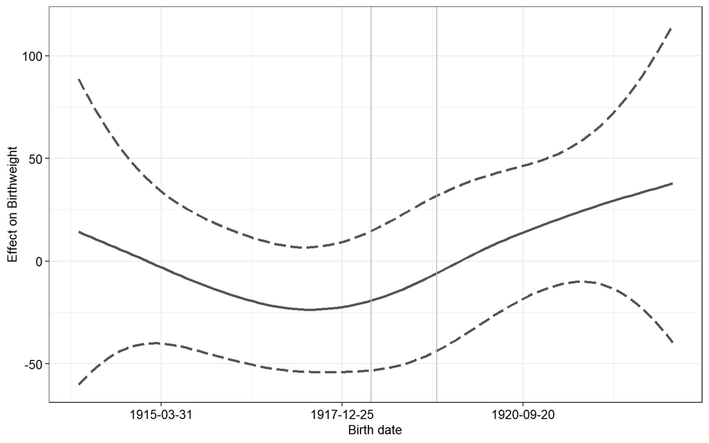

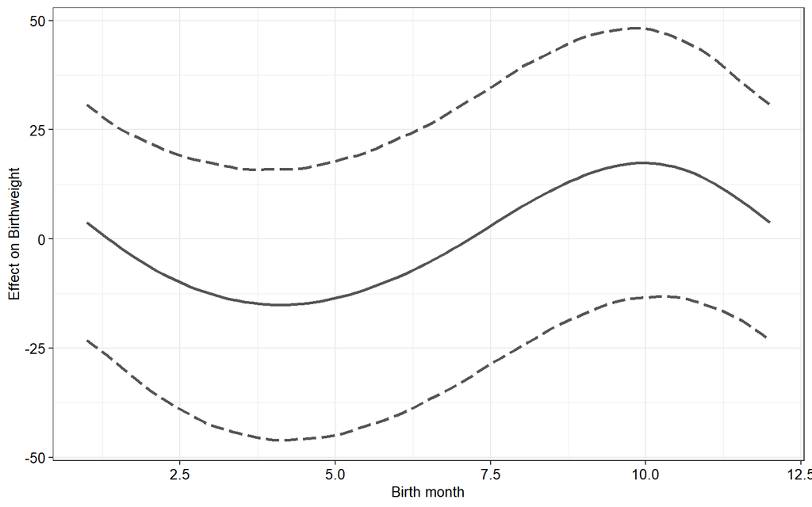

GAM regression with gestational age

```
##
## Family: gaussian
## Link function: identity
##
## Formula:
## weight ~ s(Birth_year_week_num, k = 20) + s(birth_month, bs = "cc",
##     k = 12) + boy + parity + Gest_group + matage + married +
##     city + insurance + Exposure_sum
##
## Parametric coefficients:
##                 Estimate Std. Error t value Pr(>|t|)
## (Intercept)     3237.562     30.718 105.397  < 2e-16 ***
## boy0            -145.158     11.120 -13.053  < 2e-16 ***
## parity2          131.783     15.353   8.584  < 2e-16 ***
## parity3          185.868     19.373   9.594  < 2e-16 ***
## parity>=4        237.160     18.188  13.039  < 2e-16 ***
## Gest_groupearly -351.201     15.724 -22.336  < 2e-16 ***
## matage            -1.748      1.114  -1.568   0.1168
## married0         -31.255     14.048  -2.225   0.0261 *
## city0             17.315     11.250   1.539   0.1238
## insurance1       143.832     26.602   5.407 6.64e-08 ***
## Exposure_sum       1.183      7.265   0.163   0.8706
## ---
## Signif. codes:  0 '***' 0.001 '**' 0.01 '*' 0.05 '.' 0.1 ' ' 1
##
## Approximate significance of smooth terms:
##                          edf Ref.df     F p-value
## s(Birth_year_week_num) 1.950  2.438 2.593  0.1006
## s(birth_month)         3.328 10.000 0.686  0.0683 .
## ---
## Signif. codes:  0 '***' 0.001 '**' 0.01 '*' 0.05 '.' 0.1 ' ' 1
##
## R-sq.(adj) =  0.138   Deviance explained =   14%
## GCV = 2.0302e+05  Scale est. = 2.0252e+05  n = 6574
```

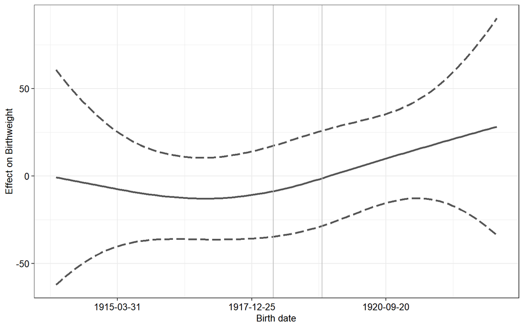

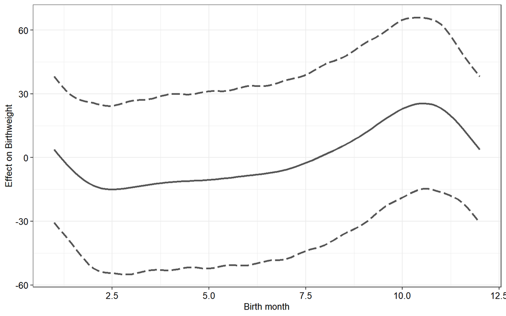

# 2 Gestational age

## 2.1 Table

| year | normal | early | total | perc_early |
| --- | --- | --- | --- | --- |
| 1914 | 647 | 105 | 752 | 13.96 |
| 1915 | 601 | 99 | 700 | 14.14 |
| 1916 | 662 | 113 | 775 | 14.58 |
| 1917 | 642 | 154 | 796 | 19.35 |
| 1918 | 611 | 131 | 742 | 17.65 |
| 1919 | 538 | 79 | 617 | 12.80 |
| 1920 | 675 | 98 | 773 | 12.68 |
| 1921 | 668 | 104 | 772 | 13.47 |
| 1922 | 572 | 92 | 664 | 13.86 |

## 2.2 Logistic Regression

I did the analysis with and without stillborns -> similar results. The results are shown with data without Stillborn. High multicollinearity between year and exposure sum and year and flu intensity. Therefor only one variable is used.

unadjusted

```
##
## Call:
## glm(formula = formula, family = binomial(link = "logit"), data = datared_still_n)
##
## Deviance Residuals:
##     Min       1Q   Median       3Q      Max
## -0.6558  -0.5614  -0.5462  -0.5207   2.0324
##
## Coefficients:
##              Estimate Std. Error z value Pr(>|z|)
## (Intercept) -1.818386   0.105211 -17.283  < 2e-16 ***
## year1915     0.014911   0.151110   0.099  0.92140
## year1916     0.050508   0.146388   0.345  0.73007
## year1917     0.390750   0.138277   2.826  0.00472 **
## year1918     0.278486   0.142617   1.953  0.05086 .
## year1919    -0.100025   0.159957  -0.625  0.53176
## year1920    -0.111359   0.150847  -0.738  0.46038
## year1921    -0.041511   0.148935  -0.279  0.78046
## year1922    -0.008964   0.153906  -0.058  0.95355
## ---
## Signif. codes:  0 '***' 0.001 '**' 0.01 '*' 0.05 '.' 0.1 ' ' 1
##
## (Dispersion parameter for binomial family taken to be 1)
##
##     Null deviance: 5524.6  on 6590  degrees of freedom
## Residual deviance: 5500.7  on 6582  degrees of freedom
## AIC: 5518.7
##
## Number of Fisher Scoring iterations: 4
```

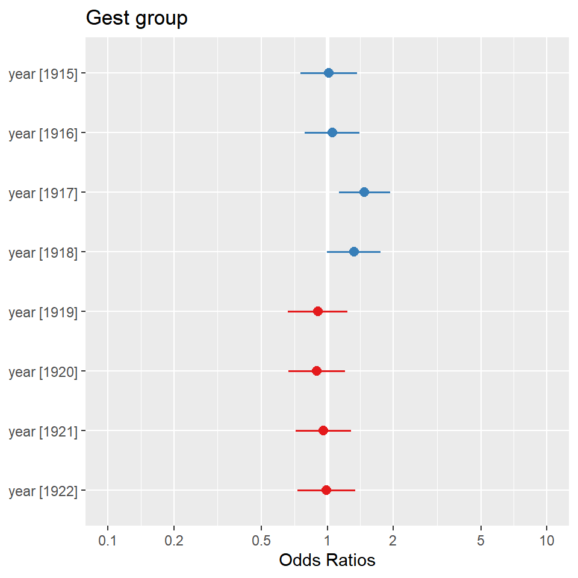

only exposure

```
##
## Call:
## glm(formula = formula, family = binomial(link = "logit"), data = datared_still_n)
##
## Deviance Residuals:
##     Min       1Q   Median       3Q      Max
## -0.5779  -0.5779  -0.5779  -0.5252   2.2079
##
## Coefficients:
##               Estimate Std. Error z value Pr(>|z|)
## (Intercept)   -1.70508    0.03776 -45.160  < 2e-16 ***
## Exposure_sum1 -0.64099    0.17845  -3.592 0.000328 ***
## Exposure_sum2 -0.20607    0.16242  -1.269 0.204519
## Exposure_sum3 -0.04412    0.14060  -0.314 0.753656
## ---
## Signif. codes:  0 '***' 0.001 '**' 0.01 '*' 0.05 '.' 0.1 ' ' 1
##
## (Dispersion parameter for binomial family taken to be 1)
##
##     Null deviance: 5524.6  on 6590  degrees of freedom
## Residual deviance: 5508.3  on 6587  degrees of freedom
## AIC: 5516.3
##
## Number of Fisher Scoring iterations: 4
```

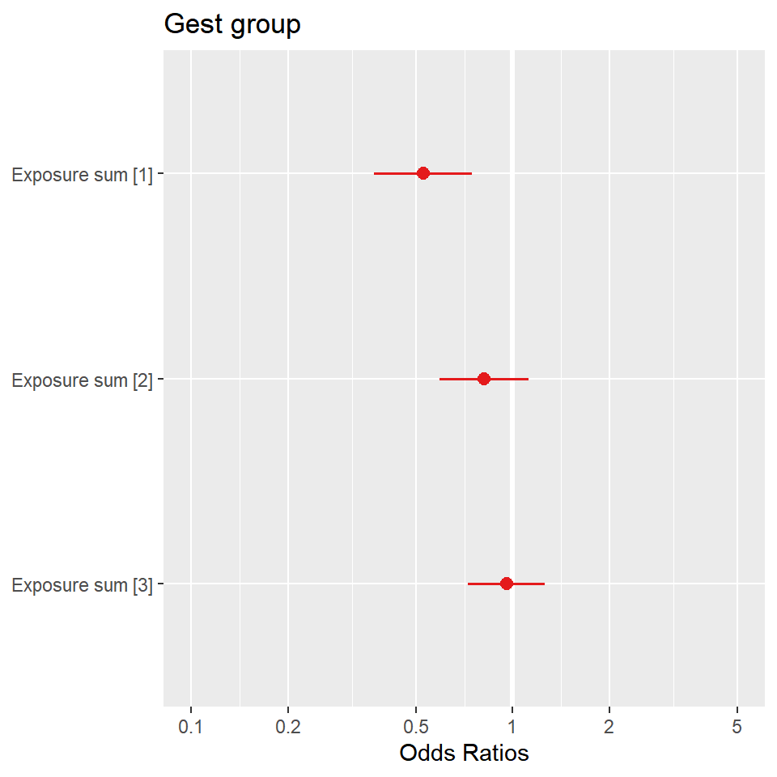

only flu intensity

```
##
## Call:
## glm(formula = formula, family = binomial(link = "logit"), data = datared_still_n)
##
## Deviance Residuals:
##     Min       1Q   Median       3Q      Max
## -0.5714  -0.5714  -0.5714  -0.5593   2.1082
##
## Coefficients:
##                   Estimate Std. Error z value Pr(>|z|)
## (Intercept)       -1.72976    0.03629 -47.662   <2e-16 ***
## Flu_intensity_all -0.38556    0.20913  -1.844   0.0652 .
## ---
## Signif. codes:  0 '***' 0.001 '**' 0.01 '*' 0.05 '.' 0.1 ' ' 1
##
## (Dispersion parameter for binomial family taken to be 1)
##
##     Null deviance: 5524.6  on 6590  degrees of freedom
## Residual deviance: 5521.0  on 6589  degrees of freedom
## AIC: 5525
##
## Number of Fisher Scoring iterations: 4
```

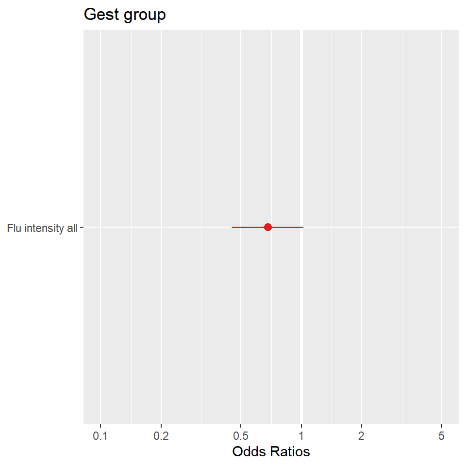

adjusted  
year

```
##
## Call:
## glm(formula = formula, family = binomial(link = "logit"), data = datared_still_n)
##
## Deviance Residuals:
##     Min       1Q   Median       3Q      Max
## -0.9057  -0.5985  -0.5271  -0.4575   2.3992
##
## Coefficients:
##                Estimate Std. Error z value Pr(>|z|)
## (Intercept)   -1.438230   0.245946  -5.848 4.98e-09 ***
## year1915       0.023578   0.152602   0.155 0.877210
## year1916       0.055925   0.148078   0.378 0.705672
## year1917       0.420728   0.139864   3.008 0.002629 **
## year1918       0.282015   0.144545   1.951 0.051050 .
## year1919      -0.102179   0.161434  -0.633 0.526768
## year1920      -0.101933   0.152412  -0.669 0.503625
## year1921      -0.050264   0.151313  -0.332 0.739748
## year1922       0.007386   0.155695   0.047 0.962163
## boy0          -0.119559   0.070419  -1.698 0.089542 .
## parity2       -0.149977   0.099008  -1.515 0.129823
## parity3       -0.271344   0.131020  -2.071 0.038358 *
## parity>=4      0.100222   0.115047   0.871 0.383679
## birth_month2  -0.302293   0.177079  -1.707 0.087802 .
## birth_month3  -0.018853   0.162446  -0.116 0.907608
## birth_month4   0.218253   0.160107   1.363 0.172828
## birth_month5  -0.118845   0.166675  -0.713 0.475824
## birth_month6   0.057667   0.165521   0.348 0.727542
## birth_month7  -0.074597   0.166753  -0.447 0.654623
## birth_month8  -0.226691   0.176085  -1.287 0.197958
## birth_month9  -0.419248   0.180439  -2.323 0.020153 *
## birth_month10 -0.342159   0.175558  -1.949 0.051298 .
## birth_month11  0.216193   0.162689   1.329 0.183892
## birth_month12 -0.180461   0.175216  -1.030 0.303041
## city0         -0.098283   0.071146  -1.381 0.167149
## matage        -0.009083   0.007168  -1.267 0.205096
## married0       0.301776   0.085301   3.538 0.000404 ***
## insurance1    -0.149592   0.182410  -0.820 0.412166
## ---
## Signif. codes:  0 '***' 0.001 '**' 0.01 '*' 0.05 '.' 0.1 ' ' 1
##
## (Dispersion parameter for binomial family taken to be 1)
##
##     Null deviance: 5501.6  on 6573  degrees of freedom
## Residual deviance: 5407.2  on 6546  degrees of freedom
##   (17 Beobachtungen als fehlend gelöscht)
## AIC: 5463.2
##
## Number of Fisher Scoring iterations: 4
```

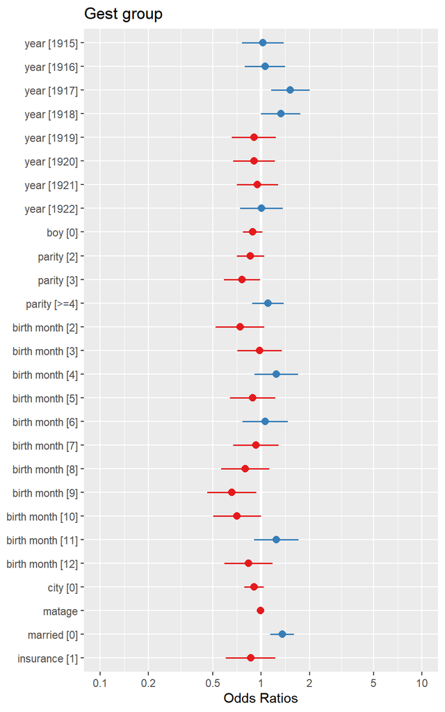

Exposure sum

```
##
## Call:
## glm(formula = formula, family = binomial(link = "logit"), data = datared_still_n)
##
## Deviance Residuals:
##     Min       1Q   Median       3Q      Max
## -0.7948  -0.6013  -0.5356  -0.4612   2.5204
##
## Coefficients:
##                Estimate Std. Error z value Pr(>|z|)
## (Intercept)   -1.307844   0.224353  -5.829 5.56e-09 ***
## boy0          -0.115894   0.070291  -1.649 0.099192 .
## parity2       -0.153756   0.098633  -1.559 0.119029
## parity3       -0.261016   0.130723  -1.997 0.045856 *
## parity>=4      0.099819   0.114496   0.872 0.383313
## birth_month2  -0.294971   0.177038  -1.666 0.095684 .
## birth_month3  -0.012455   0.162318  -0.077 0.938839
## birth_month4   0.185195   0.160096   1.157 0.247367
## birth_month5  -0.157003   0.166721  -0.942 0.346340
## birth_month6   0.051649   0.165305   0.312 0.754700
## birth_month7  -0.083180   0.166550  -0.499 0.617475
## birth_month8  -0.218584   0.175922  -1.243 0.214049
## birth_month9  -0.419235   0.180376  -2.324 0.020113 *
## birth_month10 -0.339759   0.177377  -1.915 0.055434 .
## birth_month11  0.195813   0.165798   1.181 0.237589
## birth_month12 -0.189800   0.176418  -1.076 0.281992
## city0         -0.092532   0.071073  -1.302 0.192942
## matage        -0.009269   0.007131  -1.300 0.193681
## married0       0.289723   0.085077   3.405 0.000661 ***
## insurance1    -0.153407   0.181981  -0.843 0.399237
## Exposure_sum1 -0.579638   0.181362  -3.196 0.001393 **
## Exposure_sum2 -0.204311   0.174378  -1.172 0.241337
## Exposure_sum3 -0.052793   0.142461  -0.371 0.710950
## ---
## Signif. codes:  0 '***' 0.001 '**' 0.01 '*' 0.05 '.' 0.1 ' ' 1
##
## (Dispersion parameter for binomial family taken to be 1)
##
##     Null deviance: 5501.6  on 6573  degrees of freedom
## Residual deviance: 5419.7  on 6551  degrees of freedom
##   (17 Beobachtungen als fehlend gelöscht)
## AIC: 5465.7
##
## Number of Fisher Scoring iterations: 4
```

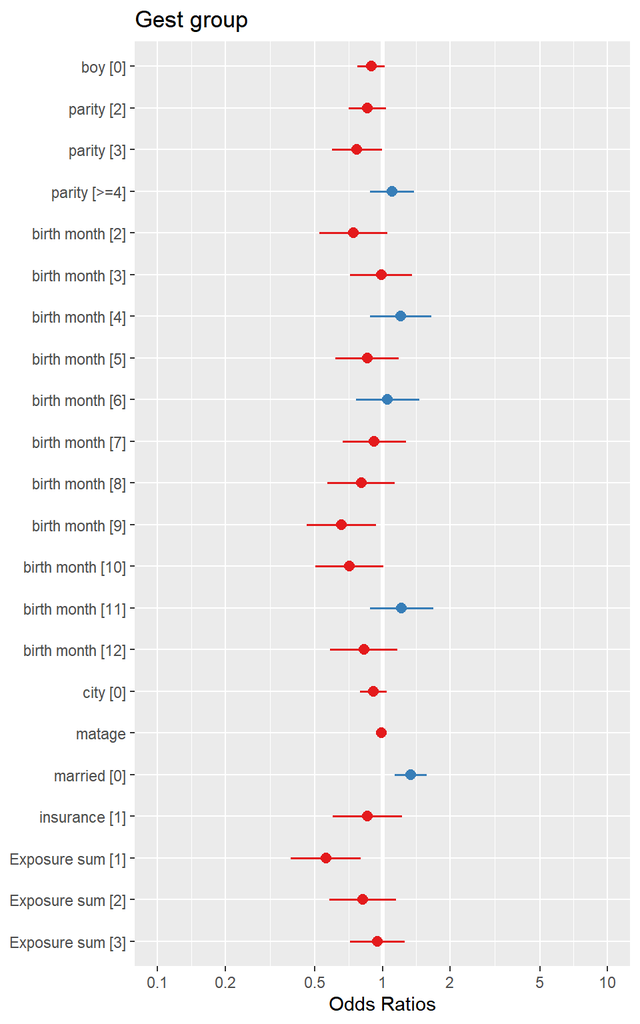

Flu_intensity_all

```
##
## Call:
## glm(formula = formula, family = binomial(link = "logit"), data = datared_still_n)
##
## Deviance Residuals:
##     Min       1Q   Median       3Q      Max
## -0.8029  -0.5982  -0.5343  -0.4691   2.3423
##
## Coefficients:
##                    Estimate Std. Error z value Pr(>|z|)
## (Intercept)       -1.341087   0.223798  -5.992 2.07e-09 ***
## boy0              -0.114424   0.070263  -1.629 0.103415
## parity2           -0.150524   0.098573  -1.527 0.126755
## parity3           -0.250218   0.130601  -1.916 0.055378 .
## parity>=4          0.106830   0.114476   0.933 0.350713
## birth_month2      -0.310857   0.176714  -1.759 0.078561 .
## birth_month3      -0.016476   0.162165  -0.102 0.919075
## birth_month4       0.233098   0.159732   1.459 0.144479
## birth_month5      -0.111067   0.166265  -0.668 0.504127
## birth_month6       0.070493   0.165075   0.427 0.669355
## birth_month7      -0.085011   0.166360  -0.511 0.609349
## birth_month8      -0.220368   0.175708  -1.254 0.209780
## birth_month9      -0.422767   0.180065  -2.348 0.018882 *
## birth_month10     -0.338910   0.175067  -1.936 0.052882 .
## birth_month11      0.199220   0.162185   1.228 0.219314
## birth_month12     -0.174753   0.174701  -1.000 0.317166
## city0             -0.098622   0.071005  -1.389 0.164847
## matage            -0.009270   0.007132  -1.300 0.193649
## married0           0.298928   0.084996   3.517 0.000437 ***
## insurance1        -0.162848   0.181793  -0.896 0.370365
## Flu_intensity_all -0.414867   0.208438  -1.990 0.046551 *
## ---
## Signif. codes:  0 '***' 0.001 '**' 0.01 '*' 0.05 '.' 0.1 ' ' 1
##
## (Dispersion parameter for binomial family taken to be 1)
##
##     Null deviance: 5501.6  on 6573  degrees of freedom
## Residual deviance: 5428.4  on 6553  degrees of freedom
##   (17 Beobachtungen als fehlend gelöscht)
## AIC: 5470.4
##
## Number of Fisher Scoring iterations: 4
```

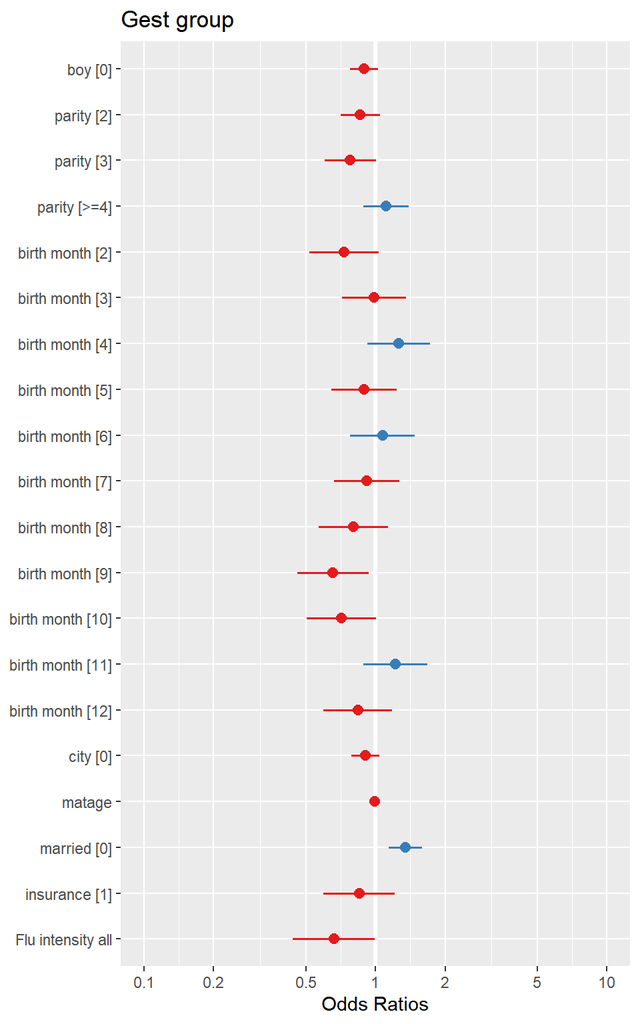

# 3 Stillborn

Data Bern

| year | alive | stillborn | perc_stillborn | alive_bfs | stillborn_bfs | perc_stillborn_bfs | Perc_diff |
| --- | --- | --- | --- | --- | --- | --- | --- |
| 1912 | 617 | 27 | 4.19 | 92196 | 2975 | 3.13 | -1.06 |
| 1913 | 718 | 28 | 3.75 | 89757 | 2846 | 3.07 | -0.68 |
| 1914 | 752 | 37 | 4.69 | 87330 | 2798 | 3.10 | -1.59 |
| 1915 | 700 | 26 | 3.58 | 75545 | 2386 | 3.06 | -0.52 |
| 1916 | 775 | 23 | 2.88 | 73660 | 2225 | 2.93 | 0.05 |
| 1917 | 796 | 28 | 3.40 | 72065 | 2060 | 2.78 | -0.62 |
| 1918 | 742 | 35 | 4.50 | 72658 | 2226 | 2.97 | -1.53 |
| 1919 | 617 | 39 | 5.95 | 72125 | 2080 | 2.80 | -3.15 |
| 1920 | 773 | 28 | 3.50 | 81190 | 2433 | 2.91 | -0.59 |
| 1921 | 772 | 35 | 4.34 | 80808 | 2365 | 2.84 | -1.50 |
| 1922 | 664 | 38 | 5.41 | 76290 | 2246 | 2.86 | -2.55 |

## 3.1 Logistic Regression

High multicollinearity between year and exposure sum and year and flu intensity. Therefor only one variable is used.

unadjusted

```
##
## Call:
## glm(formula = formula, family = binomial(link = "logit"), data = datared)
##
## Deviance Residuals:
##     Min       1Q   Median       3Q      Max
## -0.3501  -0.3099  -0.2978  -0.2630   2.6633
##
## Coefficients:
##             Estimate Std. Error z value Pr(>|z|)
## (Intercept) -3.01182    0.16839 -17.885   <2e-16 ***
## year1915    -0.28117    0.26124  -1.076   0.2818
## year1916    -0.50555    0.27042  -1.870   0.0615 .
## year1917    -0.33558    0.25559  -1.313   0.1892
## year1918    -0.04218    0.24140  -0.175   0.8613
## year1919     0.25051    0.23584   1.062   0.2881
## year1920    -0.30626    0.25567  -1.198   0.2310
## year1921    -0.08182    0.24130  -0.339   0.7346
## year1922     0.15112    0.23702   0.638   0.5237
## ---
## Signif. codes:  0 '***' 0.001 '**' 0.01 '*' 0.05 '.' 0.1 ' ' 1
##
## (Dispersion parameter for binomial family taken to be 1)
##
##     Null deviance: 2397.9  on 6879  degrees of freedom
## Residual deviance: 2383.4  on 6871  degrees of freedom
## AIC: 2401.4
##
## Number of Fisher Scoring iterations: 6
```

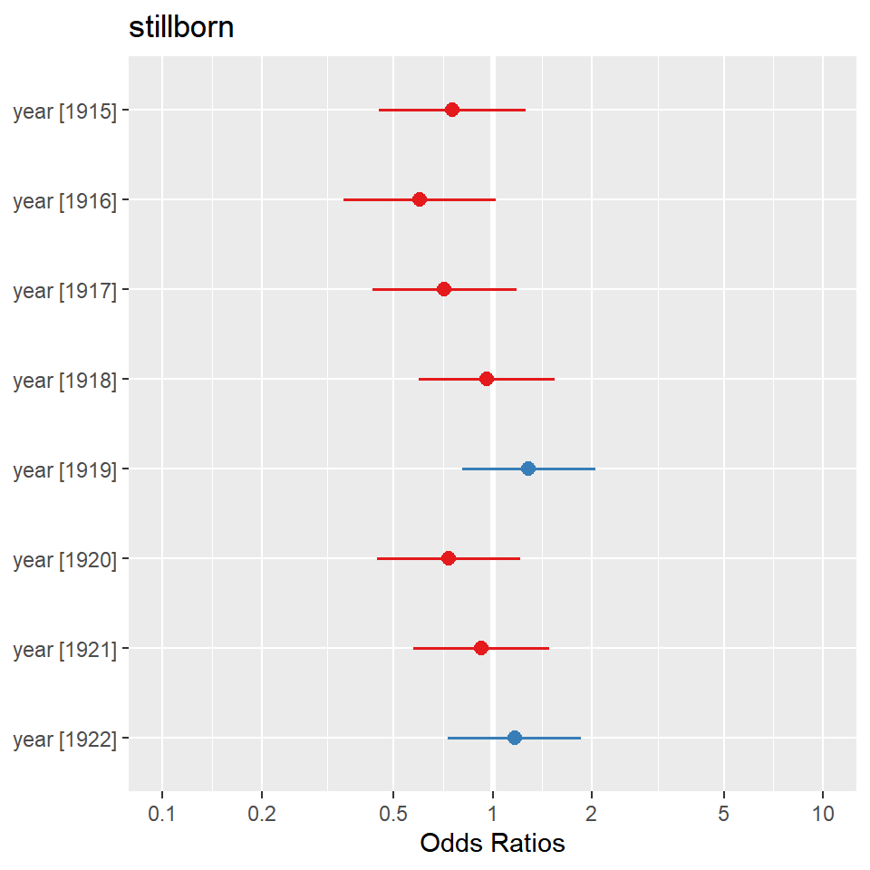

Only Exposure

```
##
## Call:
## glm(formula = formula, family = binomial(link = "logit"), data = datared)
##
## Deviance Residuals:
##     Min       1Q   Median       3Q      Max
## -0.3886  -0.2841  -0.2841  -0.2841   2.6701
##
## Coefficients:
##               Estimate Std. Error z value Pr(>|z|)
## (Intercept)   -3.18962    0.06848 -46.575  < 2e-16 ***
## Exposure_sum1 -0.34649    0.30075  -1.152  0.24928
## Exposure_sum2  0.64409    0.20786   3.099  0.00194 **
## Exposure_sum3  0.41703    0.20986   1.987  0.04690 *
## ---
## Signif. codes:  0 '***' 0.001 '**' 0.01 '*' 0.05 '.' 0.1 ' ' 1
##
## (Dispersion parameter for binomial family taken to be 1)
##
##     Null deviance: 2397.9  on 6879  degrees of freedom
## Residual deviance: 2384.5  on 6876  degrees of freedom
## AIC: 2392.5
##
## Number of Fisher Scoring iterations: 6
```

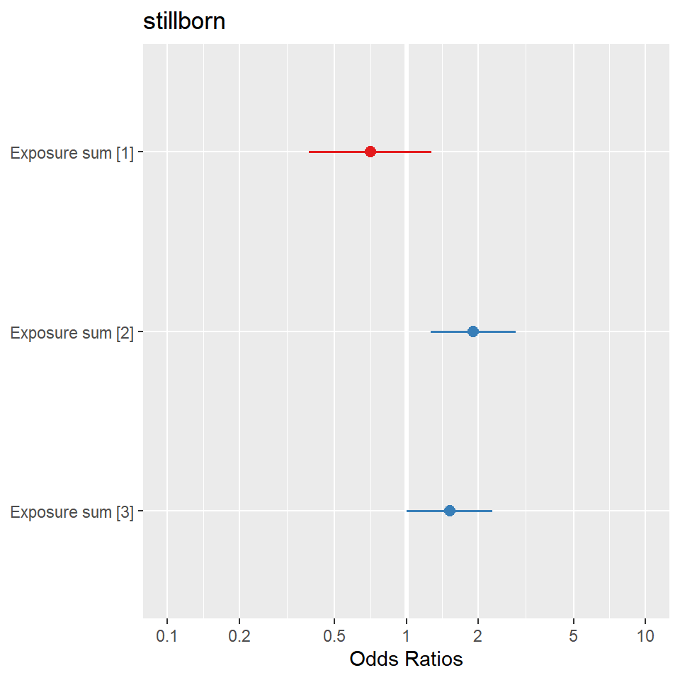

Only Flu Intensity

```
##
## Call:
## glm(formula = formula, family = binomial(link = "logit"), data = datared)
##
## Deviance Residuals:
##     Min       1Q   Median       3Q      Max
## -0.3959  -0.2860  -0.2860  -0.2860   2.5365
##
## Coefficients:
##                   Estimate Std. Error z value Pr(>|z|)
## (Intercept)        -3.1760     0.0646  -49.17   <2e-16 ***
## Flu_intensity_all   0.6826     0.2798    2.44   0.0147 *
## ---
## Signif. codes:  0 '***' 0.001 '**' 0.01 '*' 0.05 '.' 0.1 ' ' 1
##
## (Dispersion parameter for binomial family taken to be 1)
##
##     Null deviance: 2397.9  on 6879  degrees of freedom
## Residual deviance: 2392.6  on 6878  degrees of freedom
## AIC: 2396.6
##
## Number of Fisher Scoring iterations: 6
```

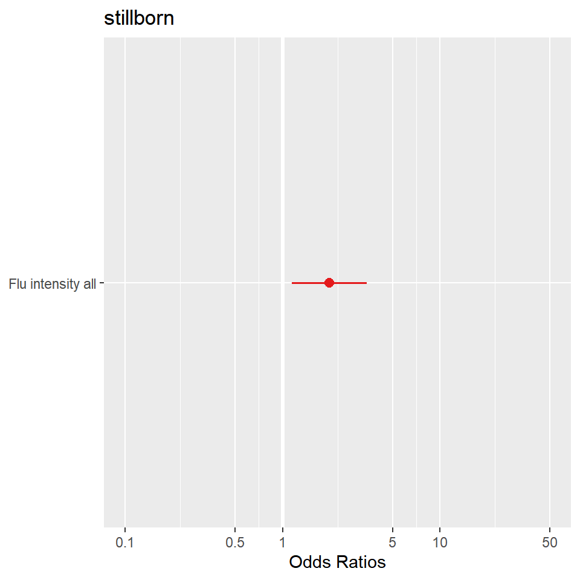

adjusted year

```
##
## Call:
## glm(formula = formula, family = binomial(link = "logit"), data = datared)
##
## Deviance Residuals:
##     Min       1Q   Median       3Q      Max
## -0.7008  -0.3138  -0.2524  -0.2108   3.0324
##
## Coefficients:
##             Estimate Std. Error z value Pr(>|z|)
## (Intercept) -5.29316    0.38399 -13.785  < 2e-16 ***
## year1915    -0.29885    0.26520  -1.127   0.2598
## year1916    -0.53507    0.27768  -1.927   0.0540 .
## year1917    -0.33362    0.25932  -1.286   0.1983
## year1918    -0.05358    0.24907  -0.215   0.8297
## year1919     0.24609    0.23999   1.025   0.3052
## year1920    -0.26893    0.25977  -1.035   0.3005
## year1921    -0.09753    0.24574  -0.397   0.6915
## year1922     0.14631    0.24308   0.602   0.5472
## boy0        -0.03234    0.12264  -0.264   0.7920
## parity2     -0.04370    0.18345  -0.238   0.8117
## parity3     -0.47704    0.25478  -1.872   0.0612 .
## parity>=4    0.15665    0.18335   0.854   0.3929
## birth_month  0.01394    0.01791   0.778   0.4363
## matage       0.07118    0.01096   6.492 8.47e-11 ***
## married0     0.05985    0.16578   0.361   0.7181
## city0        0.23996    0.12524   1.916   0.0554 .
## insurance1  -0.32738    0.32149  -1.018   0.3085
## ---
## Signif. codes:  0 '***' 0.001 '**' 0.01 '*' 0.05 '.' 0.1 ' ' 1
##
## (Dispersion parameter for binomial family taken to be 1)
##
##     Null deviance: 2364.7  on 6857  degrees of freedom
## Residual deviance: 2259.8  on 6840  degrees of freedom
##   (22 Beobachtungen als fehlend gelöscht)
## AIC: 2295.8
##
## Number of Fisher Scoring iterations: 6
```

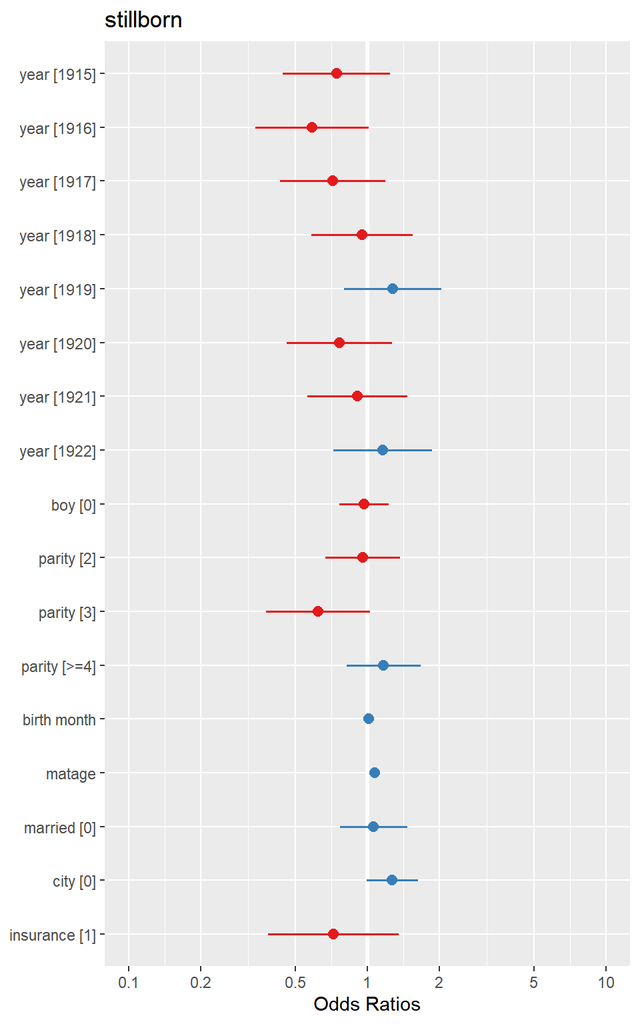

adjusted Exp

```
##
## Call:
## glm(formula = formula, family = binomial(link = "logit"), data = datared)
##
## Deviance Residuals:
##     Min       1Q   Median       3Q      Max
## -0.6996  -0.3158  -0.2497  -0.2127   2.9264
##
## Coefficients:
##                Estimate Std. Error z value Pr(>|z|)
## (Intercept)   -5.370239   0.350121 -15.338  < 2e-16 ***
## boy0          -0.037713   0.122621  -0.308  0.75842
## parity2       -0.070821   0.183395  -0.386  0.69937
## parity3       -0.496529   0.254872  -1.948  0.05140 .
## parity>=4      0.144216   0.183759   0.785  0.43256
## birth_month    0.002193   0.018973   0.116  0.90800
## matage         0.070586   0.010967   6.436 1.22e-10 ***
## married0       0.055462   0.166074   0.334  0.73841
## city0          0.248876   0.125107   1.989  0.04667 *
## insurance1    -0.295879   0.321296  -0.921  0.35711
## Exposure_sum1 -0.416720   0.316008  -1.319  0.18727
## Exposure_sum2  0.622872   0.222664   2.797  0.00515 **
## Exposure_sum3  0.432061   0.213589   2.023  0.04309 *
## ---
## Signif. codes:  0 '***' 0.001 '**' 0.01 '*' 0.05 '.' 0.1 ' ' 1
##
## (Dispersion parameter for binomial family taken to be 1)
##
##     Null deviance: 2364.7  on 6857  degrees of freedom
## Residual deviance: 2260.9  on 6845  degrees of freedom
##   (22 Beobachtungen als fehlend gelöscht)
## AIC: 2286.9
##
## Number of Fisher Scoring iterations: 6
```

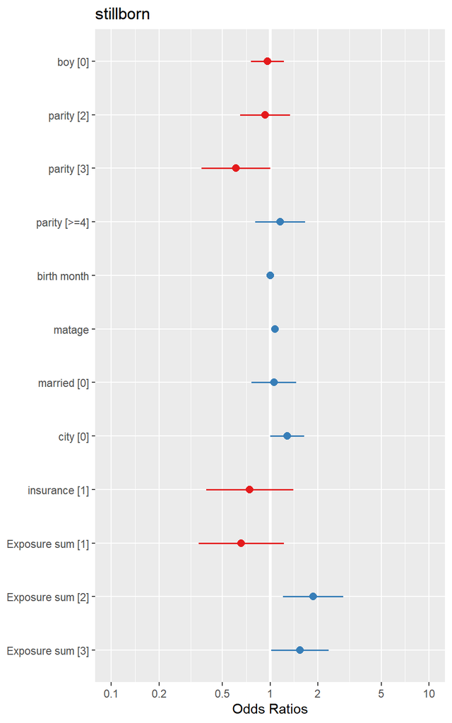

adjusted Int

```
##
## Call:
## glm(formula = formula, family = binomial(link = "logit"), data = datared)
##
## Deviance Residuals:
##     Min       1Q   Median       3Q      Max
## -0.7142  -0.3141  -0.2513  -0.2154   2.9113
##
## Coefficients:
##                   Estimate Std. Error z value Pr(>|z|)
## (Intercept)       -5.46360    0.34783 -15.708  < 2e-16 ***
## boy0              -0.03651    0.12251  -0.298   0.7657
## parity2           -0.05681    0.18316  -0.310   0.7564
## parity3           -0.49654    0.25450  -1.951   0.0511 .
## parity>=4          0.14513    0.18344   0.791   0.4289
## birth_month        0.01732    0.01790   0.968   0.3332
## matage             0.07065    0.01096   6.448 1.13e-10 ***
## married0           0.05796    0.16580   0.350   0.7266
## city0              0.24700    0.12496   1.977   0.0481 *
## insurance1        -0.29794    0.32095  -0.928   0.3532
## Flu_intensity_all  0.69079    0.28624   2.413   0.0158 *
## ---
## Signif. codes:  0 '***' 0.001 '**' 0.01 '*' 0.05 '.' 0.1 ' ' 1
##
## (Dispersion parameter for binomial family taken to be 1)
##
##     Null deviance: 2364.7  on 6857  degrees of freedom
## Residual deviance: 2268.6  on 6847  degrees of freedom
##   (22 Beobachtungen als fehlend gelöscht)
## AIC: 2290.6
##
## Number of Fisher Scoring iterations: 6
```

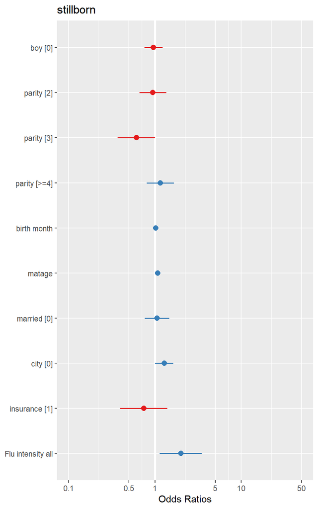